# 项目整体介绍

本项目共分为4子个程序

程序1（数据处理、训练及A榜预测）：https://aistudio.baidu.com/aistudio/projectdetail/2194480

程序2（B榜预测）：https://aistudio.baidu.com/aistudio/projectdetail/2249860

程序3（增强对比度）：https://aistudio.baidu.com/aistudio/projectdetail/2194972

程序4（投票系统）： https://aistudio.baidu.com/aistudio/projectdetail/2242631

[figure not shown]

## 以下内容是 程序1（数据处理、训练及A榜预测）

# 一、数据预处理

## 1 解压数据集

默认解压到/data目录下，该目录会在每次进入环境时重置，但可以节省项目启动时间。

```python
!unzip -oq /home/aistudio/data/data95249/train_image.zip -d data/
!unzip -oq /home/aistudio/data/data95249/train_50k_mask.zip -d data/
!unzip -oq /home/aistudio/data/data95249/第一阶段test.zip -d data/
```

## 2 导入所需库

```python
import os
import numpy as np
import paddle
from PIL import Image

# 显示图片
import matplotlib.pyplot as plt # plt 用于显示图片
import matplotlib.image as mpimg # mpimg 用于读取图片
import numpy as np
import random

# 处理预测图片
import cv2
import zipfile
import shutil
```

## 3 定义超参

```python
#每个类别中验证集的数量
eval_num_per_category = 10
#训练图片路径
train_images_path="data/train_image"
#标签路径
label_images_path="data/train_50k_mask"
#测试图片路径
test_images_path="data/val_image"
#A榜标签路径
test_label_path="data/pred_07-22_solution_4_processed"
```

## 4 原始图片与其标签 数据路径载入np array

```python
#封装好的获取所有图片路径的函数
from utils import get_path
from utils import get_test_data
#扩展一维，以便将images与labels合并
images=np.expand_dims(np.array(get_path(train_images_path)),axis=1)
labels=np.expand_dims(np.array(get_path(label_images_path)),axis=1)
data=np.array(np.concatenate((images,labels),axis=1))
print(images[0])
print(labels[0])
print(data[0])
#打乱数据，同时也不会影响images与labels的对应关系
np.random.shuffle(data)



############### 加入A榜最优标签作为B榜训练集 ################
# #封装好的获取所有图片路径的函数
# from utils import get_path
# from utils import get_test_data
# #扩展一维，以便将images与labels合并
# images_O=np.expand_dims(np.array(get_path(train_images_path)),axis=1)
# labels_O=np.expand_dims(np.array(get_path(label_images_path)),axis=1)
# data_O=np.array(np.concatenate((images_O,labels_O),axis=1))
# print(images_O[0])
# print(labels_O[0])
# print(data_O[0])

# images_A=np.expand_dims(np.array(get_test_data(test_images_path)),axis=1)
# labels_A=np.expand_dims(np.array(get_test_data(test_label_path)),axis=1)
# data_A=np.array(np.concatenate((images_A,labels_A),axis=1))
# print(images_A[0])
# print(labels_A[0])
# print(data_A[0])

# data = np.vstack((data_O,data_A))
# print(data)
# #打乱数据，同时也不会影响images与labels的对应关系
# np.random.shuffle(data)
```

```
['data/train_image/n01443537/n01443537_10149.png']
['data/train_50k_mask/n01443537/n01443537_10149.png']
['data/train_image/n01443537/n01443537_10149.png'
 'data/train_50k_mask/n01443537/n01443537_10149.png']
```

## 5 尝试随机显示一张图片 和 对应标签

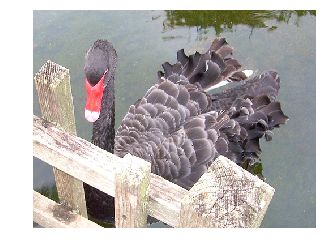

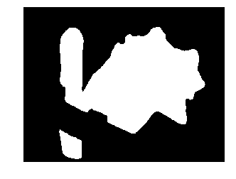

```python
def show_image(image_1):
    lena = mpimg.imread(image_1,0)
    plt.imshow(lena) # 显示图片
    plt.axis('off') # 不显示坐标轴
    plt.show()

index = random.randint(0, 49999)
show_image(data[index][0])
show_image(data[index][1])
```

## 6 数据集检查

```python
#读取一张图片，并显示其对应像素的通道数值
img=Image.open("/home/aistudio/data/train_image/n03014705/n03014705_2658.png")
img_array=img.load()
print(img.size) # 图片大小
print(img_array[0,0]) # [0,0]位置的通道数值

# 检查该图片除了(0,0,0)以外是否有其他通道数值
values = []
for i in range(img.size[0]):
    for j in range(img.size[1]):
        if img_array[i,j]!=(0,0,0):
            if img_array[i,j] not in values:
                values.append(img_array[i,j])
print("For this figure, besides (0,0,0), there are " + str(len(values)) + " kinds of different values")
```

```
(500, 380)
(98, 98, 86)
For this figure, besides (0,0,0), there are 42890 kinds of different values
```

```python
# 检查每一个标签图片的通道数量
one_channel = 0
three_channels = 0
others = 0

for i in range (len(labels)):
    img=Image.open(labels[i][0])
    if len(img.split()) == 3:
        three_channels = three_channels +1
    elif len(img.split()) == 1:
        one_channel = one_channel +1
    else:
        others = others + 1
# 打印检查结果
print("one_channel: " + str(one_channel))
print("three_channels: " + str(three_channels))
print("others: " + str(others))
```

```
one_channel: 0
three_channels: 50000
others: 0
```

# 二、引入PaddleSeg

## 0 图片种类提取，依据种类分割数据集

```python
# 首先检查一下共有多少个种类的图片
file_names = os.listdir(train_images_path)
file_names = sorted(file_names)
print(len(file_names))
print(file_names[0])
print(os.path.join(train_images_path, file_names[0]) )
# 测试一下是否能找到对应的index
for index, fn in enumerate(file_names):
    if fn in data[1][0]:
        print(index)
```

```
500
n01443537
data/train_image/n01443537
497
```

```python
# 分割数据集

train_data = []
eval_data = []
for index_classification, fn in enumerate(file_names):
    count = 0
    for index_data, image_and_label in enumerate(data):
        if count < eval_num_per_category:
            if fn in image_and_label[0]:
               eval_data.append(image_and_label)
               count = count + 1
        else:
            if fn in image_and_label[0]:
                train_data.append(image_and_label)
                count = count + 1

print(len(train_data))
print(len(eval_data))

test_data=get_test_data(test_images_path)
print(test_data.shape)


############### 加入A榜最优标签作为B榜训练集 ################
# # 分割数据集
# train_data = []
# eval_data = []
# count = 0
# for index_data, image_and_label in enumerate(data):
#     if count < eval_num_per_category -1 :
#         train_data.append(image_and_label)
#         count = count + 1
#     else:
#         eval_data.append(image_and_label)
#         count = 0

# print(len(train_data))
# print(len(eval_data))
```

```
45000
5000
(11878, 1)
```

## 1 将image路径、label路径、图片种类一起写入txt文件

```python
np.random.shuffle(train_data)
np.random.shuffle(eval_data)

if os.path.exists("data/train.txt"):
    os.remove("data/train.txt")
if os.path.exists("data/val.txt"):
    os.remove("data/val.txt")
if os.path.exists("data/test.txt"):
    os.remove("data/test.txt")

# 依据PaddleSeg数据集格式要求，写文件
with open("data/train.txt", 'w', encoding="utf-8") as f:
    for i in range(len(train_data)):
        for index, fn in enumerate(file_names):
            if fn in train_data[i][0]:
                f.write("{} {} {}\n".format(train_data[i][0], train_data[i][1],index))

with open("data/val.txt", 'w', encoding="utf-8") as f:
    for i in range(len(eval_data)):
        for index, fn in enumerate(file_names):
            if fn in eval_data[i][0]:
                f.write("{} {} {}\n".format(eval_data[i][0], eval_data[i][1],index))

with open("data/test.txt", 'w', encoding="utf-8") as f:
    for i in range(len(test_data)):
        f.write("{}\n".format(test_data[i][0]))



############### 加入A榜最优标签作为B榜训练集 ################
# np.random.shuffle(train_data)
# np.random.shuffle(eval_data)

# if os.path.exists("data/train.txt"):
#     os.remove("data/train.txt")
# if os.path.exists("data/val.txt"):
#     os.remove("data/val.txt")

# # 依据PaddleSeg数据集格式要求，写文件
# with open("data/train.txt", 'w', encoding="utf-8") as f:
#     for i in range(len(train_data)):
#         f.write("{} {}\n".format(train_data[i][0], train_data[i][1]))

# with open("data/val.txt", 'w', encoding="utf-8") as f:
#     for i in range(len(eval_data)):
#         f.write("{} {}\n".format(eval_data[i][0], eval_data[i][1]))
```

```
#######################
line: data/train_image/n03777568/n03777568_5652.png data/train_50k_mask/n03777568/n03777568_5652.png 412
```

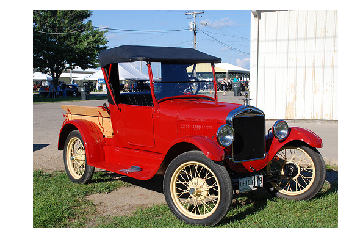

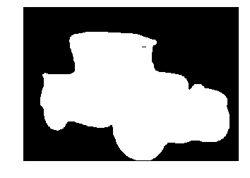

```
index: 412
#######################
#######################
line: data/train_image/n01592084/n01592084_22795.png data/train_50k_mask/n01592084/n01592084_22795.png 15
```

[figure not shown]

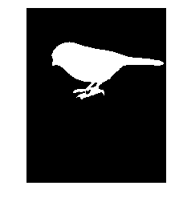

[output not shown]

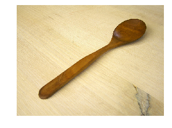

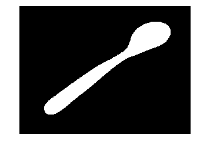

```python
#检查是否能够读取图片
count = 0
with open('data/train.txt', 'r')  as f:
    for line in f.readlines():
        values = line.strip().split(" ")
        image_path = values[0]
        label_path = values[1]
        index = values[2]
        print("#######################")
        print("line: " + line)
        show_image(image_path)
        show_image(label_path)
        print("index: " + str(index))
        print("#######################")
        count = count + 1
        if count==3:
            break
```

## 2 安装PaddleSeg （此处运行一次即可）

```python
# 安装PaddleSeg
# ! pip install paddleseg

# 下载PaddleSeg代码
# ! git clone https://gitee.com/paddlepaddle/PaddleSeg.git
```

[output not shown]

```python
# 运行验证
# ! python PaddleSeg/train.py --config PaddleSeg/configs/quick_start/bisenet_optic_disc_512x512_1k.yml
```

[output not shown]

[output cut: 42 more lines]

[output not shown]

## 3 修改PadleSeg包中的文件

主要修改如下项目 PaddleSeg/paddleseg/datasets/dataset.py

修改后的具体文件是：

dataset(2分类和501分类).py

dataset(加入A榜最优解_2分类).py

即在数据处理中加入如下代码，确保符合PaddleSeg的要求

- if len(items) != 3: # 将原来的2改为3，多了index数据
- image_path = items[0] #路径获取避免冲入出现“root”参数中的路径

  label_path = items[1]

  classification = items[2]

### 2分类的模型中

label = label[:, :, 0] #获取三维数组中的第一维所有数据，作为标签

if max(np.unique(label))>1:

label = label/255.

label = label.astype("int64")

### 501分类的模型中

label = label[:, :, 0] #获取三维数组中的第一维所有数据，作为标签

if max(np.unique(label)) >1:

label = label/255.

label = label * (classification + 1)

label = label.astype("int64")

### 加入A榜最优结果时需要做如下修改

if len(items) != 2:

并去掉关于classification的代码，因为A榜没有分类信息

## 4 开启使用PaddleSeg的训练

修改PaddleSeg包并训练参数，并进行训练

### 检查图片的大小（仅适用于501分类，因为太大的图片无法批量处理）

```python
#检查val图片大小
# 501分类无法连续处理多个太大的图片
# 需要把它们先拿出去不使用，用剩下的图片来作为val.txt的图片
# 创建val_less_than_2000.txt文件，并移除太大的图片

count = 0
with open('data/val.txt', 'r')  as f:
#with open('data/val_less_than_2000.txt', 'r')  as f:
    for line in f.readlines():
        values = line.strip().split(" ")
        image_path = values[0]
        label_path = values[1]
        index = values[2]
        im = Image.open(image_path)
        if im.size[0]>=2000 or im.size[1]>=2000:
            print(line)
            # print("#######################")
            # print("line: " + line)
            # show_image(image_path)
            # show_image(label_path)
            # print("index: " + str(index))
            # print("#######################")
            count = count + 1
print("shape large " + str(count))
```

```
shape large 0
```

```python
#检查test图片大小
# 501分类无法连续处理多个太大的图片
# 需要把它们先拿出去，用这个模型预测剩下的图片
# （之后再用之前2分类最优的模型预测这些大图片）
# 创建test_less_than_2000.txt文件，并移除太大的图片


count = 0
with open('test.txt', 'r')  as f:
#with open('data/test_less_than_2000.txt', 'r')  as f:
    for line in f.readlines():
        values = line.strip().split(" ")
        image_path = values[0]
        im = Image.open(image_path)
        if im.size[0]>=2000 or im.size[1]>=2000:
            print(line)
            # print("#######################")
            # print("line: " + line)
            # show_image(image_path)
            # print("index: " + str(index))
            # print("#######################")
            count = count + 1
        else:
            values = line.strip().split("/")
            image_name = values[2]
            shutil.copy(image_path, 'data/val_image_less_than_2000/' + image_name)
print("shape large " + str(count))
```

```
data/val_image/ILSVRC2012_val_00012141.JPEG

data/val_image/ILSVRC2012_val_00037348.JPEG

data/val_image/ILSVRC2012_val_00027941.JPEG

data/val_image/ILSVRC2012_val_00030408.JPEG

data/val_image/ILSVRC2012_val_00032370.JPEG

data/val_image/ILSVRC2012_val_00013889.JPEG

data/val_image/ILSVRC2012_val_00018903.JPEG

data/val_image/ILSVRC2012_val_00006661.JPEG

data/val_image/ILSVRC2012_val_00043188.JPEG

data/val_image/ILSVRC2012_val_00002037.JPEG

data/val_image/ILSVRC2012_val_00040245.JPEG

data/val_image/ILSVRC2012_val_00033687.JPEG

data/val_image/ILSVRC2012_val_00049752.JPEG

data/val_image/ILSVRC2012_val_00041704.JPEG

data/val_image/ILSVRC2012_val_00013491.JPEG

data/val_image/ILSVRC2012_val_00035830.JPEG

data/val_image/ILSVRC2012_val_00021883.JPEG

data/val_image/ILSVRC2012_val_00037004.JPEG

data/val_image/ILSVRC2012_val_00046975.JPEG

data/val_image/ILSVRC2012_val_00014066.JPEG

data/val_image/ILSVRC2012_val_00048174.JPEG

data/val_image/ILSVRC2012_val_00008240.JPEG

data/val_image/ILSVRC2012_val_00039884.JPEG

data/val_image/ILSVRC2012_val_00041570.JPEG

data/val_image/ILSVRC2012_val_00024274.JPEG

shape large 25
```

## 5 进行训练

```python
# 2分类训练
############################  Solution 1  ##############################
# dataset: just randomly shuffled  0.77435
# config:deeplabv3p  backbone:resnet50
# batch_size: 64  iters: 20000     num_classes: 2
# optimizer: sgd   momentum: 0.9   weight_decay: 4.0e-5
# lr_scheduler: PolynomialDecay   learning_rate: 0.01   end_lr: 0   power: 0.9
# loss: CrossEntropyLoss   coef: [1]
########################################################################
# !python PaddleSeg/train.py \
#     --config PaddleSeg/configs/deeplabv3p/deeplabv3p_resnet50_os8_voc12aug_512x512_40k.yml \
#     --do_eval \
#     --use_vdl \
#     --save_dir /home/aistudio/output \
#     --save_interval 2000

############################  Solution 2  ##############################
# dataset: just randomly shuffled   0.77842
# config:deeplabv3p  backbone:resnet101
# batch_size: 40  iters: 32000
# optimizer: sgd   momentum: 0.9   weight_decay: 4.0e-5
# lr_scheduler: PolynomialDecay   learning_rate: 0.01   end_lr: 0   power: 0.9
# loss:  CrossEntropyLoss + LovaszSoftmaxLoss       coef: [0.8, 0.2]
########################################################################
# !python PaddleSeg/train.py \
#     --config tranning_1.yml \
#     --do_eval \
#     --use_vdl \
#     --save_dir /home/aistudio/output \
#     --save_interval 2000

############################  Solution 3  ##############################
# dataset: randomly shuffled per category (8:2)  0.76211
# config:OCRNet  backbone:HRNet_W18
# batch_size: 90  iters: 15000    num_classes: 2
# optimizer: sgd   momentum: 0.9   weight_decay: 4.0e-5
# lr_scheduler: PolynomialDecay   learning_rate: 0.01   end_lr: 0   power: 0.9
# loss:  (CrossEntropyLoss + LovaszSoftmaxLoss)*2    coef: [0.8, 0.2]*2   coef: [1, 0.4]
########################################################################
# !python PaddleSeg/train.py \
#     --config trainning_2.yml \
#     --do_eval \
#     --use_vdl \
#     --save_dir /home/aistudio/output \
#     --save_interval 1000


############################  Solution 4  ##############################
# dataset: randomly shuffled per category (8:2)  0.77874
# config:DeeplabV3P  backbone:resnet101
# batch_size: 40  iters: 50000      num_classes: 2
# optimizer: sgd   momentum: 0.9   weight_decay: 4.0e-5
# lr_scheduler: PolynomialDecay   learning_rate: 0.01   end_lr: 0   power: 0.9
# loss:  CrossEntropyLoss + LovaszSoftmaxLoss       coef: [0.8, 0.2]
########################################################################
# !python PaddleSeg/train.py \
#     --config trainning_3.yml \
#     --do_eval \
#     --use_vdl \
#     --save_dir /home/aistudio/output \
#     --save_interval 1000

# 501分类训练
############################  Solution 5  ##############################
# dataset: randomly shuffled per category (8:2)   0.49759      0.69608
# config:DeeplabV3P  backbone:resnet101
# batch_size: 20  iters: 50000     num_classes: 501
# optimizer: sgd   momentum: 0.9   weight_decay: 4.0e-5
# lr_scheduler: PolynomialDecay   learning_rate: 0.01   end_lr: 0   power: 0.9
# loss:  (CrossEntropyLoss + LovaszSoftmaxLoss)  coef: [0.8, 0.2]
# 0.11685 0.19506 0.25929 0.29833 0.33738 0.34889 0.40112 0.40169
########################################################################
# !python PaddleSeg/train.py \
#     --config trainning_4.yml \
#     --do_eval \
#     --use_vdl \
#     --save_dir /home/aistudio/output \
#     --save_interval 1000

############################  Solution 6  ##############################
# dataset: randomly shuffled per category (8:2)
# 29000   0.57352   0.74319
# 42000   0.57856   0.75054
# config:DeeplabV3P  backbone:resnet50
# batch_size: 20  iters: 50000     num_classes: 501
# optimizer: sgd   momentum: 0.9   weight_decay: 4.0e-5
# lr_scheduler: PolynomialDecay   learning_rate: 0.01   end_lr: 0   power: 0.9
# loss:  CrossEntropyLoss   coef: [1]
# 2021-07-23 01:23:54 iter 10
# 2021-07-23 18:13:06 iter 25010
# 40 min/ 1000 iter（training + evalutation）
# mIoU:  0.2287  0.3114  0.3756  0.4066  0.4325  0.4190  0.4698  0.4635  0.5045
#0.4861  0.5179  0.5039  0.5263  0.5298  0.5545  0.5521  0.5663  0.5730  0.5822
#0.5826  0.5946  0.5981  0.6045  0.6052  0.6107  0.6079  0.6123  0.6162  0.6144
#0.6230  0.6237  0.6243  0.6264  0.6224  0.6255  0.6308  0.6290  0.6305  0.6295
#0.6293  0.6305  0.6311  0.6298  0.6281
########################################################################
# !python PaddleSeg/train.py \
#     --config trainning_5.yml \
#     --do_eval \
#     --use_vdl \
#     --save_dir /home/aistudio/output \
#     --save_interval 1000

############################  Solution 7  ##############################
# dataset: randomly shuffled per category (8:2)
# config:DeeplabV3P  backbone:resnet50
# batch_size: 20  iters: 50000     num_classes: 501
# optimizer: sgd   momentum: 0.9   weight_decay: 4.0e-5
# lr_scheduler: PolynomialDecay   learning_rate: 0.1   end_lr: 0   power: 0.9
# loss:  CrossEntropyLoss   coef: [1]
# 2021-07-24 07:16:23  iter 10
# 2021-07-24 07:56:18  iter 1010
# 40  min/ 1000 iter（training + evalutation）
# mIoU:  0.0014   0.0020
########################################################################
# !python PaddleSeg/train.py \
#     --config trainning_6.yml \
#     --do_eval \
#     --use_vdl \
#     --save_dir /home/aistudio/output \
#     --save_interval 1000

############################  Solution 8  ##############################
# dataset: randomly shuffled per category (8:2)
# config:DeeplabV3P  backbone:resnet50
# batch_size: 20  iters: 50000     num_classes: 501
# optimizer: sgd   momentum: 0.9   weight_decay: 4.0e-5
# lr_scheduler: PolynomialDecay   learning_rate: 0.001   end_lr: 0   power: 0.9
# loss:  CrossEntropyLoss   coef: [1]
# save_iterval 3000
# 2021-07-24 08:38:58  iter 10
# 2021-07-24 09:18:42  iter 1010
# 40  min/ 1000 iter（training + evalutation）
# mIoU: 0.1008 0.3876
# save_iterval 3000
# 2021-07-24 10:09:13  iter 10
# 2021-07-24 11:25:01  iter 3010
# 75  min/ 3000 iter（training + evalutation）
# mIoU:         0.5228  0.6235  0.6439   0.6575  0.6652  0.6658  0.6740  0.6748 0.6774
# loss: 6.8198  0.7420  0.4025  0.2981   0.2672  0.2179  0.2215  0.1778  0.1971 0.1621  0.1582
########################################################################
# !python PaddleSeg/train.py \
#     --config trainning_7.yml \
#     --do_eval \
#     --use_vdl \
#     --save_dir /home/aistudio/output \
#     --save_interval 3000
```

```python
############################  Solution 9  ##############################
# dataset: randomly shuffled per category (8:2)
# config:DeeplabV3P  backbone:resnet50
# batch_size: 20  iters: 50000     num_classes: 501
# optimizer: sgd   momentum: 0.9   weight_decay: 4.0e-5
# lr_scheduler: PolynomialDecay   learning_rate: 0.0001   end_lr: 0   power: 0.9
# loss:  CrossEntropyLoss   coef: [1]
# save_iterval 3000
# 2021-07-24 17:53:12  iter 10
# 2021-07-24 19:10:54  iter 3010
# 78  min/ 3000 iter（training + evalutation）
# mIoU:         0.0020
# loss: 6.0884  2.0769
########################################################################
# !python PaddleSeg/train.py \
#     --config trainning_8.yml \
#     --do_eval \
#     --use_vdl \
#     --save_dir /home/aistudio/output \
#     --save_interval 3000

############################  Solution 10  ##############################
# dataset: randomly shuffled per category (8:2)
# config:DeeplabV3P  backbone:resnet50
# batch_size: 5  iters: 200000     num_classes: 501
# optimizer: sgd   momentum: 0.9   weight_decay: 4.0e-5
# lr_scheduler: PolynomialDecay   learning_rate: 0.001   end_lr: 0   power: 0.9
# loss:  CrossEntropyLoss   coef: [1]
# save_iterval 10000
# 2021-07-24 23:11:24  iter 10
#  iter 10010
# min/ 10000 iter（training + evalutation）
# mIoU:
# loss: 6.6569
########################################################################
# !python PaddleSeg/train.py \
#     --config trainning_9.yml \
#     --do_eval \
#     --use_vdl \
#     --save_dir /home/aistudio/output \
#     --save_interval 10000


###########################  Solution 10 [512, 512] ##############################
# dataset: randomly shuffled per category (8:2)
# config:DeeplabV3P  backbone:resnet50
# batch_size: 4  iters: 400000     num_classes: 501
# optimizer: sgd   momentum: 0.9   weight_decay: 4.0e-5
# lr_scheduler: PolynomialDecay   learning_rate: 0.001   end_lr: 0   power: 0.9
# loss:  CrossEntropyLoss   coef: [1]
# save_iterval 10000
# 2021-07-24 23:11:24  iter 10
#  iter 10010
# min/ 10000 iter（training + evalutation）
# mIoU:
# loss: 6.6569
#######################################################################
# !python PaddleSeg/train.py \
#     --config trainning_10.yml \
#     --do_eval \
#     --use_vdl \
#     --save_dir /home/aistudio/output \
#     --save_interval 100

############################  Solution 11 501 classes  ##############################
# dataset: randomly shuffled per category (8:2)
# config:ORCNet  backbone:HRNet_W48
# batch_size: 20  iters: 50000     num_classes: 501
# optimizer: sgd   momentum: 0.9   weight_decay: 4.0e-5
# lr_scheduler: PolynomialDecay   learning_rate: 0.001   end_lr: 0   power: 0.9
# loss:  CrossEntropyLoss*2   coef: [1:0.4]
# save_iterval 5000
# 2021-07-24 10:09:13  iter 10
# 2021-07-24 11:25:01  iter 3010
# 75  min/ 3000 iter（training + evalutation）
# mIoU:         0.5228  0.6235  0.6439   0.6575  0.6652  0.6658  0.6740  0.6748 0.6774  0.6778
# loss: 6.8198  0.7420  0.4025  0.2981   0.2672  0.2179  0.2215  0.1778  0.1971 0.1621  0.1582
########################################################################
# !python PaddleSeg/train.py \
#     --config trainning_10_OCRNet.yml \
#     --do_eval \
#     --use_vdl \
#     --save_dir /home/aistudio/output \
#     --save_interval 5000


############################  Solution 12 num_classes: 2 ##############################
# dataset: randomly shuffled per category (8:2)
# config:deeplabv3p  backbone:resnet101
# batch_size: 40  iters: 32000
# optimizer: sgd   momentum: 0.9   weight_decay: 4.0e-5
# lr_scheduler: PolynomialDecay   learning_rate: 0.01   end_lr: 0   power: 0.9
# loss:  CrossEntropyLoss + LovaszSoftmaxLoss       coef: [0.8, 0.2]
# save_iterval 4000
# 2021-07-25 07:57:11 iter 10
# 2021-07-25 10:54:53 iter 4010
# 180 min/ 4000 iter（training + evalutation）
# mIoU:            [0.921  0.8171] 0.8691    [0.9236 0.8173] 0.8705
# loss: 0.5687            0.1141 (4000)          0.0793  (8000)
# epoch:                       1~4                     5~8
# A: 0.74124     0.76107
##############################
# Change the Batch Szie to 2
# save_iterval 20000
# 2021-07-25 15:28:33 iter 10
# 2021-07-25 16:53:03 iter 20010
# 85 min/ 20000 iter（training + evalutation）
# mIoU:           [0.7993  0.4912] 0.6455   [0.8233 0.6147] 0.7190    [0.8233 0.6147] 0.7388
# loss: 0.7626          0.3849 (2000)            0.2972(4000)               0.2731(6000)
# epoch:                      1                       2                         3
##############################
# Change the LR to 0.001
# save_iterval 3000
# 2021-07-25  19:48:43  iter 10
# 2021-07-25  22:03:55  iter 3010
# 135 min/ 3000 iter（training + evalutation）
# mIoU:            [0.9208 0.8137] 0.8672    [0.9256 0.8225] 0.8741    [0.9262 0.823 ] 0.8746    [0.9268 0.8262] 0.8765   [0.9275 0.8275] 0.8775
# loss: 0.6312           0.1369(3000)               0.1092(6000)          0.0965(9000)                0.1014(12000)            0.0883（15000）
# epoch:                     1-3                       4-6                    7-9                         10-12                    13-15
# A: 0.75331
##############################
# Change the LR to 0.001
# Change resize to [128, 128]
# save_iterval 3000
# 2021-07-26  08:21:22   iter 10
# 2021-07-26  08:46:45   iter 260
# 25 min/ 260 iter（training + evalutation）
# mIoU:            [0.8809 0.7188] 0.7998    [0.8898 0.7455] 0.8177    [0.895  0.7468] 0.8209    [0.8978 0.7626] 0.8302    [0.8993 0.7645] 0.8319
# loss: 0.6312           0.2281(250)               0.2011(500)              0.1925(750)                0.1792(1000)             0.1734（1250）
# epoch:                     1                         2                        3                           4                         5
# A:
##############################
# Change the LR to 0.01
# Change RandomPaddingCrop to [128, 128]
# save_iterval 3000
# 2021-07-26  10:37:09   iter 10
# 2021-07-26     iter 260
# 25 min/ 260 iter（training + evalutation）
# mIoU:            [0.8562 0.701 ] 0.7786    [0.8758 0.7236] 0.7997    [0.8743 0.7264]0.8003
# loss: 0.5359          0.3111(250)                0.3074(500)               0.3004(750)               0.3057(1000)
# epoch:                     1                         2                         3                           4                         5
# A:
########################################################################
# !python PaddleSeg/train.py \
#     --config tranning_1.yml \
#     --do_eval \
#     --use_vdl \
#     --save_dir /home/aistudio/output \
#     --save_interval 250
##############################
# Change the LR to 0.0001
# save_iterval 1000
# 2021-07-27  13:09:43  iter 10
# 2021-07-27  14:01:18  iter 1010
# 52 min/ 1000 iter（training + evalutation）
# mIoU:        [0.8516 0.6649] 0.7582   [0.8899 0.7486] 0.8193  [0.8992 0.7649]0.8321  [0.9036 0.7728] 0.8382
# loss: 0.8777     0.2769(1000)              0.2091(2000)           0.1911(3000)           0. 1967(4000)
# epoch:                     1                     2                    3                         4
# mIoU:        [0.905 0.78 ] 0.8425
# loss:            0.1743(5000)              0.1701(6000)           (7000)          (8000)
# epoch:                     5                     6                    7                         8
# A:
##############################
# !python PaddleSeg/train.py \
#     --config trainning_1_0001.yml \
#     --do_eval \
#     --use_vdl \
#     --save_dir /home/aistudio/output \
#     --save_interval 1000
```

```python
############################  Solution 13 - 1  ##############################
# dataset: randomly shuffled per category (8:2)
# config:deeplabv3p  backbone:resnet101
# batch_size: 40  iters: 32000
# RandomPaddingCrop crop_size: [256, 256]
# optimizer: sgd   momentum: 0.9   weight_decay: 4.0e-5
# lr_scheduler: PolynomialDecay   learning_rate: 0.001   end_lr: 0   power: 0.9
# loss:  CrossEntropyLoss + LovaszSoftmaxLoss       coef: [0.8, 0.2]
#
# 2021-07-26 13:09:30 iter 10
# 2021-07-26 16:07:02 iter 4010
# 180 min / 2000 iters
# mIoU:            [0.9074 0.7932]  0.8503     [0.9171 0.8078]0.8625    [0.9194 0.8096] 0.8645   [0.9215 0.8136]0.8676
# loss: 0.7060        0.2268  (4000)                 0.1732(8000)             0.1930(12000)           0.2012（16000）
# epoch:                  1~4                             5~8                     9~12                   13～16
# mIoU:            [0.9217 0.8144]  0.8680     [0.9195 0.8151]0.8673    [0.9224 0.8171] 0.8698   [0.9226 0.8186]0.8706
# loss: 0.7060        0.1677  (20000)                 0.1369(24000)            0.1409(28000)         0.1364（32000）
# epoch:                  17~20                          21~24                    25~28                   29～32
# A: 0.72456
########################################################################
# !python PaddleSeg/train.py \
#     --config tranning_1_extended.yml \
#     --do_eval \
#     --use_vdl \
#     --save_dir /home/aistudio/output \
#     --save_interval 4000


############################  Solution 13 - 2 ##############################
# dataset: randomly shuffled per category (8:2)
# config:deeplabv3p  backbone:resnet101
# batch_size: 40  iters: 32000
# RandomPaddingCrop crop_size: [256, 256]
# optimizer: sgd   momentum: 0.9   weight_decay: 4.0e-5
# lr_scheduler: PolynomialDecay   learning_rate: 0.01   end_lr: 0   power: 0.9
# loss:  CrossEntropyLoss + LovaszSoftmaxLoss       coef: [0.8, 0.2]
#
# 2021-07-26 10:48:59 iter 10
# 2021-07-26 12:21:36 iter 2010
# 95 min / 2000 iters
# mIoU:             [0.8935 0.7617] 0.8276   [0.9023 0.7819] 0.8421    [0.9027 0.7809] 0.8418    [0.9085 0.7903]0.8494
# loss: 0.6875            0.2729(2000)            0.2374(4000)               0.2105(6000)              0.2329(8000)
# epoch:                      1~2                     3~4                       5~6                         7~8
# mIoU:             [0.91 0.7945] 0.8522     [0.9103 0.7957] 0.8530    [0.9113 0.7983]0.8548     [0.9078 0.7929] 0.8504
# loss:                   0.2156(10000)           0.2122(12000)            0.1960（14000）              0.2152（16000）
# epoch:                      9~10                    11~12                   13～14                       15～16
# mIoU:             [0.9122 0.8024] 0.8573     [0.9179 0.807 ] 0.8625    [0.9173 0.8079]0.8626    [0.9179 0.809 ] 0.8634
# loss:                   0.1933(18000)           0.1747(20000)            0.1313（22000）              0.1269（24000）
# epoch:                      17~18                    19~20                  21～22                       23～24
# mIoU:             [0.9199 0.812 ] 0.8660    [0.9202 0.8127]0.8664      [0.9203 0.8149] 8676     [0.9212 0.8162] 0.8687
# loss:                   0.1933(26000)           0.1307 (28000)           0.1199（30000）             0.1254（32000）
# epoch:                      25~26                   27~28                    29～30                      31～31
########################################################################
# !python PaddleSeg/train.py \
#     --config tranning_1_extended.yml \
#     --do_eval \
#     --use_vdl \12
#     --save_dir /home/aistudio/output \2
#     --save_interval 2000


############################  Solution 14 -1  ##############################
# dataset: randomly shuffled per category (8:2)
# config:ORCNet  backbone:HRNet_W48
# batch_size: 50  iters: 20000     num_classes: 2
# optimizer: sgd   momentum: 0.9   weight_decay: 4.0e-5
# lr_scheduler: PolynomialDecay   learning_rate: 0.01   end_lr: 0   power: 0.9
# loss:  CrossEntropyLoss*2   coef: [1:0.4]
# save_iterval 800
# 2021-07-27 18:36:12 iter 10
# 2021-07-27 19:17:39iter 810
# 42 min/ 800 iter（training + evalutation
# loss: 0.7330
# epoch: 1, iter: 800/20000, loss: 0.2049,  mIoU: 0.8616 [0.9155 0.8076] Acc: 0.9376 [0.97   0.8632] Kappa: 0.8495
# epoch: 2, iter: 1600/20000, loss: 0.1703, mIoU: 0.8684 [0.922  0.8148] Acc: 0.9419 [0.9619 0.8922] Kappa: 0.8574
# epoch: 3, iter: 2400/20000, loss: 0.1761, mIoU: 0.8684 [0.921  0.8157] Acc: 0.9415 [0.9665 0.8814] Kappa: 0.8574
# epoch: 4, iter: 3200/20000, loss: 0.1369, mIoU: 0.8707 [0.923  0.8185] Acc: 0.9428 [0.965  0.8887] Kappa: 0.8601
# epoch: 5, iter: 4000/20000, loss: 0.1296, mIoU: 0.8670 [0.9203 0.8137] Acc: 0.9409 [0.9656 0.8813] Kappa: 0.8558
# epoch: 6, iter: 4800/20000, loss: 0.1109, mIoU: 0.8714 [0.9243 0.8185] Acc: 0.9435 [0.9609 0.8997] Kappa: 0.8608
# epoch: 7, iter: 5600/20000, loss: 0.1068, mIoU: 0.8726 [0.924  0.8212] Acc: 0.9437 [0.9662 0.8889] Kappa: 0.8623
########################################################################
# !python PaddleSeg/train.py \
#     --config trainning_10_OCRNet.yml \
#     --do_eval \
#     --use_vdl \
#     --save_dir /home/aistudio/output \
#     --save_interval 800

############################  Solution 14 - 2 ##############################
# dataset: randomly shuffled per category (8:2)
# config:ORCNet  backbone:HRNet_W48
# batch_size: 50  iters: 20000     num_classes: 2
# optimizer: sgd   momentum: 0.9   weight_decay: 4.0e-5
# lr_scheduler: PolynomialDecay   learning_rate: 0.0001   end_lr: 0   power: 0.9
# loss:  CrossEntropyLoss*2   coef: [1:0.4]
# save_iterval 800
# 2021-07-27 12:48:47 iter 10
# 2021-07-27 13:30:54 iter 810
# 42 min/ 800 iter（training + evalutation
# mIoU:       [0.8939 0.7487] 0.8213  [0.905  0.7747] 0.8398  [0.9111 0.7913] 0.8512  [0.9131 0.7901] 0.8516
# loss: 0.9593      0.3188(800)           0.2707 (1600)           0.2619（2400）            0.2594(3200）
# epoch:                    1                   2                    3                      4
# mIoU:       [0.9153 0.802 ] 0.8586   [0.9173 0.8037] 0.8605 [0.9155 0.8003]0.8579
# loss:            0.2247(4000)           0.2085(4800)           0.2174（5600）            (6400）
# epoch:                    5                   6                    7                      8
########################################################################
# !python PaddleSeg/train.py \
#     --config trainning_10_OCRNet.yml \
#     --do_eval \
#     --use_vdl \
#     --save_dir /home/aistudio/output \
#     --save_interval 800
```

```python
############################  Solution 14 and 15 501 classes  ##############################
# dataset: randomly shuffled per category (8:2)
# config:deeplabv3p  backbone:resnet101
# batch_size: 16  iters: 32000     num_classes: 501
# optimizer: sgd   momentum: 0.9   weight_decay: 4.0e-5
# lr_scheduler: PolynomialDecay   learning_rate: 0.01   end_lr: 0   power: 0.9
# loss:  CrossEntropyLoss  LovaszSoftmaxLoss   coef: [0.8, 0.2]
# save_iterval 2500
# 2021-07-27 21:27:37 iter 10
# 2021-07-27 23:04:54 iter 2510
# 97 min/ 2500 iter（training + evalutation）
# loss: 3.5696
# epoch: 1, iter: 2500/32000, loss: 1.2195, lr: 0.009294, mIoU: 0.1369 Acc: 0.7293 Kappa: 0.4415
# epoch: 2, iter: 5000/32000, loss: 0.7739, lr: 0.008582, mIoU: 0.2704 Acc: 0.7923 Kappa: 0.5724
# epoch: 3, iter: 7500/32000, loss: 0.8365, lr: 0.007864, mIoU: 0.3293 Acc: 0.8137 Kappa: 0.6148
# epoch: 4, iter: 10000/32000, loss: 0.7379, lr: 0.007138,mIoU: 0.3671 Acc: 0.8169 Kappa: 0.632
# epoch: 5, iter: 12500/32000, loss: 0.5776, lr: 0.006403,mIoU: 0.4260 Acc: 0.8414 Kappa: 0.6788
# epoch: 6, iter: 15000/32000, loss: 0.4471, lr: 0.005660,mIoU: 0.4775 Acc: 0.8592 Kappa: 0.7134
# epoch: 7, iter: 17500/32000, loss: 0.4063, lr: 0.004908,mIoU: 0.5066 Acc: 0.8676 Kappa:
# epoch: 8, iter: 20000/32000, loss: 0.2754, lr: 0.004146,mIoU: 0.5464 Acc: 0.8804 Kappa:
# epoch: 9, iter: 22500/32000, loss: 0.1940, lr: 0.003365,mIoU: 0.5740 Acc: 0.8865 Kappa:
# epoch: 10,iter: 25000/32000, loss: 0.1867, lr: 0.002553,mIoU: 0.5937 Acc: 0.8921 Kappa:
# epoch: 11,iter: 27500/32000, loss: 0.1387, lr: 0.001663,mIoU: 0.6026 Acc: 0.8952 Kappa:
# epoch: 12,iter: 30000/32000, loss: 0.1066, lr: 0.000795,mIoU: 0.6125 Acc: 0.8990 Kappa:
# epoch: 13,iter: 32000/32000, loss: 0.1427, lr: 0.000088,mIoU: 0.6157 Acc: 0.9001 Kappa:
# !python PaddleSeg/train.py \
#     --config trainning_14_v3p_101_501.yml \
#     --do_eval \
#     --use_vdl \
#     --save_dir /home/aistudio/output \
#     --save_interval 2500
############################
# Change the LR to 0.0001
# loss: 5.9137
# epoch: 1, iter: 2500/32000, loss: 1.7603, lr: 0.000093, mIoU: 0.0089 Acc: 0.7204 Kappa: 0.0374
##########################.   Solution 15 501 classes   ##
# Change the LR to 0.0005
# loss: 5.6027
# epoch: 1, iter: 2500/32000, loss: 0.9305, lr: 0.000465, mIoU: 0.3930 Acc: 0.8440 Kappa: 0.6262
# epoch: 2, iter: 5000/32000, loss: 0.4735, lr: 0.000429, mIoU: 0.5988 Acc: 0.8936 Kappa: 0.7735
# epoch: 3, iter: 7500/32000, loss: 0.3705, lr: 0.000393, mIoU: 0.6457 Acc: 0.9043 Kappa: 0.8024
# epoch: 4, iter: 10000/32000, loss: 0.3669, lr: 0.000357, mIoU: 0.6589 Acc: 0.9059 Kappa: 0.8071
# epoch: 5, iter: 12500/32000, loss: 0.3244, lr: 0.000320, mIoU: 0.6843 Acc: 0.9130 Kappa: 0.8230
# epoch: 6, iter: 15000/32000, loss: 0.2592, lr: 0.000283, mIoU: 0.6919 Acc: 0.9160 Kappa: 0.8294
# epoch: 7, iter: 17500/32000, loss: 0.2375, lr: 0.000245, mIoU: 0.6955 Acc: 0.9167 Kappa: 0.8314
# epoch: 8, iter: 20000/32000, loss: 0.2160, lr: 0.000207, mIoU: 0.6942 Acc: 0.9170 Kappa: 0.8309
# epoch: 9, iter: 22500/32000, loss: 0.2012, lr: 0.000168, mIoU: 0.7014 Acc: 0.9196 Kappa: 0.8356
# epoch: 10, iter: 25000/32000, loss: 0.2031, lr: 0.000127,mIoU: 0.7046 Acc: 0.9203 Kappa: 0.8376
# epoch: 11, iter: 27500/32000, loss: 0.1954, lr: 0.000086,mIoU: 0.7047 Acc: 0.9198 Kappa: 0.8371
# epoch: 12, iter: 30000/32000, loss: 0.1994, lr: 0.000041,mIoU: 0.7066 Acc: 0.9206 Kappa: 0.8389
# epoch: 13, iter: 32000/32000, loss: 0.1610, lr: 0.000000,mIoU: 0.7073 Acc: 0.9204 Kappa: 0.8388
#
########################################################################
# !python PaddleSeg/train.py \
#     --config trainning_14_v3p_101_501_0005.yml \
#     --do_eval \
#     --use_vdl \
#     --save_dir /home/aistudio/output \
#     --save_interval 2500


############################  Solution 15 enlarge Deeplab v3p ##############################
# dataset: randomly shuffled per category (8:2)
# config:ORCNet  backbone:HRNet_W48
# batch_size: 16  iters: 100000     num_classes: 2
# optimizer: sgd   momentum: 0.9   weight_decay: 4.0e-5
# lr_scheduler: PolynomialDecay   learning_rate: 0.0005   end_lr: 0   power: 0.9
# loss:  CrossEntropyLoss LovaszSoftmaxLoss   coef: [0.8, 0.2]
########################################################################
# !python PaddleSeg/train.py \
#     --config solution15_enlarge_DV3P.yml \
#     --do_eval \
#     --use_vdl \
#     --save_dir /home/aistudio/output \
#     --save_interval 2500

############################  Solution 16 enlarge ORCNet ##############################
# dataset: randomly shuffled per category (8:2)
# config:ORCNet  backbone:HRNet_W48
# batch_size: 16  iters: 500000     num_classes: 2
# optimizer: sgd   momentum: 0.9   weight_decay: 4.0e-5
# lr_scheduler: PolynomialDecay   learning_rate: 0.001   end_lr: 0   power: 0.9
# loss:  CrossEntropyLoss*2   coef: [1:0.4]
########################################################################
# !python PaddleSeg/train.py \
#     --config solution16_enlarge_ORC.yml \
#     --do_eval \
#     --use_vdl \
#     --save_dir /home/aistudio/output \
#     --save_interval 2500

############################  Solution 16 ##############################
# dataset: randomly shuffled per category (8:2)
# config:ORCNet  backbone:HRNet_W48
# batch_size: 16  iters: 500000     num_classes: 2
# optimizer: sgd   momentum: 0.9   weight_decay: 4.0e-5
# lr_scheduler: PolynomialDecay   learning_rate: 0.001   end_lr: 0   power: 0.9
# loss:  CrossEntropyLoss*2   coef: [1:0.4]
# save_iterval 2500
# 2021-07-29 19:34:03 iter 10
# 2021-07-29 20:20:35 iter 2510
# 44 min/ 2000 iter
# loss: 0.8975
# epoch: 1, iter: 2500/500000, loss: 0.2021, lr: 0.000996, mIoU: 0.8628 [0.9175 0.8081] Acc: 0.9388 [0.9648 0.8763] Kappa: 0.8509
# epoch: 2, iter: 5000/500000, loss: 0.1987, lr: 0.000991, mIoU: 0.8698 [0.9219 0.8176] Acc: 0.9422 [0.9669 0.8828] Kappa: 0.8591
# epoch: 3, iter: 7500/500000, loss: 0.1937, lr: 0.000986, mIoU: 0.8702 [0.9235 0.8169] Acc: 0.9430 [0.9608 0.8978] Kappa: 0.8595
# epoch: 4, iter: 10000/500000, loss: 0.1537, lr: 0.000982,mIoU: 0.8684 [0.9233 0.8135] Acc: 0.9425 [0.9559 0.9074] Kappa: 0.8573
# epoch: 5, iter: 12500/500000, loss: 0.1519, lr: 0.000977,mIoU: 0.8732 [0.9244 0.822 ] Acc: 0.9440 [0.9663 0.8895] Kappa: 0.8630
# epoch: 6, iter: 15000/500000, loss: 0.1274, lr: 0.000973,mIoU: 0.8731 [0.9252 0.821 ] Acc: 0.9443 [0.962  0.8997] Kappa: 0.8628
# epoch: 7, iter: 17500/500000, loss: 0.1376, lr: 0.000968,mIoU: 0.8740 [0.9249 0.823 ] Acc: 0.9444 [0.9662 0.891 ] Kappa: 0.8639
########################################################################
# !python PaddleSeg/train.py \
#     --config trainning_16.yml \
#     --do_eval \
#     --use_vdl \
#     --save_dir /home/aistudio/output \
#     --save_interval 2500
```

```python
############################  Solution 17 ##############################
# dataset: randomly shuffled per category (8:2)
# config:ORCNet  backbone:HRNet_W48
# batch_size: 16  iters: 500000     num_classes: 2
# optimizer: sgd   momentum: 0.9   weight_decay: 4.0e-5
# lr_scheduler: PolynomialDecay   learning_rate: 0.001   end_lr: 0   power: 0.9
# loss:  (CrossEntropyLoss  LovaszSoftmaxLoss   coef: [0.8, 0.2])*2  coef: [1, 0.4]
# save_iterval 2500
# 2021-08-02 08:06:33 iter 10
# 2021-08-02 08:57:28 iter 2510
# 41 min/ 2000 iter
# loss: 0.8699
# epoch: 1, iter: 2500/500000, loss: 0.1963, lr: 0.000996, mIoU: 0.8637 Acc: 0.9389 Kappa: 0.8520
# epoch: 2, iter: 5000/500000, loss: 0.2022, lr: 0.000991, mIoU: 0.8687 Acc: 0.9417 Kappa: 0.8578                                                                         0.8687 Acc: 0.9417 Kappa: 0.8578
# epoch: 3, iter: 7500/500000, loss: 0.1915, lr: 0.000986, mIoU: 0.8724 Acc: 0.9438 Kappa: 0.8620
# epoch: 4, iter: 10000/500000, loss: 0.1846, lr: 0.000982, mIoU: 0.8692 Acc: 0.9428 Kappa: 0.8582
# epoch: 5, iter: 12500/500000, loss: 0.1615, lr: 0.000977, mIoU: 0.8733 Acc: 0.9442 Kappa: 0.8631
# epoch: 6, iter: 15000/500000, loss: 0.1295, lr: 0.000973, mIoU: 0.8742 Acc: 0.9450 Kappa: 0.8642
# epoch: 7, iter: 17500/500000, loss: 0.1431, lr: 0.000968, mIoU: 0.8708 Acc: 0.9431 Kappa: 0.8601
# epoch: 8, iter: 20000/500000, loss: 0.1039, lr: 0.000964, mIoU: 0.8737 Acc: 0.9447 Kappa: 0.8635
# epoch: 9, iter: 22500/500000, loss: 0.1000, lr: 0.000959, mIoU: 0.8747 Acc: 0.9448 Kappa: 0.8647
# epoch: 10, iter: 25000/500000, loss: 0.0986, lr: 0.000955,mIoU: 0.8728 Acc: 0.9441 Kappa: 0.8625
# epoch: 11, iter: 27500/500000, loss: 0.1143, lr: 0.000950,mIoU: 0.8761 Acc: 0.9455 Kappa: 0.8663
# epoch: 12, iter: 30000/500000, loss: 0.1113, lr: 0.000946,mIoU: 0.8770 Acc: 0.9458 Kappa: 0.8674
# epoch: 13, iter: 32500/500000, loss: 0.0992, lr: 0.000941,mIoU: 0.8776 Acc: 0.9462 Kappa: 0.8681
# epoch: 14, iter: 35000/500000, loss: 0.0936, lr: 0.000937,mIoU: 0.8760 Acc: 0.9454 Kappa: 0.8663
# epoch: 15, iter: 37500/500000, loss: 0.1008, lr: 0.000932,mIoU (0.8776)
# epoch: 16, iter: 40000/500000, loss: 0.0933, lr: 0.000928,mIoU: 0.8770 Acc: 0.9458 Kappa: 0.8674
# epoch: 17, iter: 42500/500000, loss: 0.0793, lr: 0.000923,mIoU: 0.8781 Acc: 0.9465 Kappa: 0.8687
# epoch: 18, iter: 45000/500000, loss: 0.0945, lr: 0.000919,mIoU: 0.8775 Acc: 0.9461 Kappa: 0.8681
# epoch: 19, iter: 47500/500000, loss: 0.0681, lr: 0.000914, ?
# epoch: 20, iter: 50000/500000, loss: 0.0747, lr: 0.000910, ?
# epoch: 21, iter: 52500/500000, loss: 0.0805, lr: 0.000905, ?
# epoch: 22, iter: 55000/500000, loss: 0.0688, lr: 0.000900, ?
# epoch: 23, iter: 57500/500000, loss: 0.0749, lr: 0.000896, ?  mIoU (0.8803) was saved at iter 57500.
# epoch: 24, iter: 60000/500000, loss: 0.0620, lr: 0.000891, ?
# epoch: 25, iter: 62500/500000, loss: 0.0718, lr: 0.000887, mIoU: 0.8791 Acc: 0.9470 Kappa: 0.8698
# epoch: 26, iter: 65000/500000, loss: 0.0672, lr: 0.000882, ?
# epoch: 27, iter: 67500/500000, loss: 0.0693, lr: 0.000878, ?
# epoch: 28, iter: 70000/500000, loss: 0.0723, lr: 0.000873, mIoU: 0.8790 Acc: 0.9468 Kappa: 0.8697
########################################################################
# !python PaddleSeg/train.py \
#     --config trainning_17.yml \
#     --do_eval \
#     --use_vdl \
#     --save_dir /home/aistudio/output \
#     --save_interval 2500


###########################  Solution 18  RandomPaddingCrop ##############################
# dataset: randomly shuffled per category (8:2)
# config:ORCNet  backbone:HRNet_W48
# batch_size: 50  iters: 20000     num_classes: 2
# optimizer: sgd   momentum: 0.9   weight_decay: 4.0e-5
# lr_scheduler: PolynomialDecay   learning_rate: 0.0005   end_lr: 0   power: 0.9
# loss:  （CrossEntropyLoss * LovaszSoftmaxLoss [0.8, 0.2] ）* 2     coef: [1, 0.4]
# save_iterval 800# loss: 0.9132
# epoch: 1, iter: 800/500000, loss: 0.3180, lr: 0.000499, mIoU: 0.8332 Acc: 0.9251 Kappa: 0.8151
# epoch: 2, iter: 1600/500000, loss: 0.2877, lr: 0.000499,mIoU: 0.8474 Acc: 0.9307 Kappa: 0.8326
# epoch: 3, iter: 2400/500000, loss: 0.3097, lr: 0.000498,mIoU: 0.8556 Acc: 0.9353 Kappa: 0.8424
# epoch: 4, iter: 3200/500000, loss: 0.3115, lr: 0.000497,mIoU: 0.8564 Acc: 0.9349 Kappa: 0.8435
# epoch: 5, iter: 4000/500000, loss: 0.2904, lr: 0.000496,mIoU: 0.8605 Acc: 0.9376 Kappa: 0.8482
# epoch: 6, iter: 4800/500000, loss: 0.2802, lr: 0.000496,mIoU: 0.8635 Acc: 0.9390 Kappa: 0.8517
# epoch: 7, iter: 5600/500000, loss: 0.2933, lr: 0.000495,mIoU: 0.8640 Acc: 0.9392 Kappa: 0.8524
# epoch: 8, iter: 6400/500000, loss: 0.2980, lr: 0.000494,mIoU: 0.8657 Acc: 0.9399 Kappa: 0.8543
# epoch: 9, iter: 7200/500000, loss: 0.2504, lr: 0.000494,mIoU: 0.8662 Acc: 0.9405 Kappa: 0.8548
# epoch: 10, iter: 8000/500000, loss: 0.2923, lr: 0.000493, mIoU: 0.8671 Acc: 0.9405 Kappa: 0.8560
# epoch: 11, iter: 8800/500000, loss: 0.2607, lr: 0.000492, mIoU: 0.8677 Acc: 0.9409 Kappa: 0.8566
# epoch: 12, iter: 9600/500000, loss: 0.2718, lr: 0.000491, mIoU: 0.8694 Acc: 0.9418 Kappa: 0.8587
# epoch: 13, iter: 10400/500000, loss: 0.2380, lr: 0.000491,mIoU: 0.8685 Acc: 0.9413 Kappa: 0.8577
# epoch: 14, iter: 11200/500000, loss: 0.2536, lr: 0.000490,mIoU: 0.8693 Acc: 0.9416 Kappa: 0.8586
# epoch: 15, iter: 12000/500000, loss: 0.2356, lr: 0.000489,mIoU: 0.8703 Acc: 0.9426 Kappa: 0.8597
# epoch: 16, iter: 12800/500000, loss: 0.2673, lr: 0.000488,mIoU: 0.8710 Acc: 0.9431 Kappa: 0.8604
# epoch: 17, iter: 13600/500000, loss: 0.2378, lr: 0.000488,mIoU: 0.8715 Acc: 0.9433 Kappa: 0.8610
# epoch: 18, iter: 14400/500000, loss: 0.2382, lr: 0.000487,mIoU: 0.8736 Acc: 0.9443 Kappa: 0.8634
# epoch: 19, iter: 15200/500000, loss: 0.2275, lr: 0.000486,mIoU: 0.8726 Acc: 0.9435 Kappa: 0.8624
# epoch: 20, iter: 16000/500000, loss: 0.2294, lr: 0.000486,mIoU: 0.8720 Acc: 0.9436 Kappa: 0.8616
# epoch: 22, iter: 17600/500000, loss: 0.2106, lr: 0.000484,mIoU: 0.8743 Acc: 0.9444 Kappa: 0.8643
# epoch: 23, iter: 18400/500000, loss: 0.2136, lr: 0.000483,mIoU: 0.8739 Acc: 0.9440 Kappa: 0.8640
# epoch: 24, iter: 19200/500000, loss: 0.2103, lr: 0.000483,mIoU: 0.8728 Acc: 0.9437 Kappa: 0.8626
# epoch: 25, iter: 20000/500000, loss: 0.2282, lr: 0.000482,mIoU: 0.8738 Acc: 0.9439 Kappa: 0.8638
# epoch: 26, iter: 20800/500000, loss: 0.2145, lr: 0.000481,mIoU: 0.8748 Acc: 0.9447 Kappa: 0.8649
# epoch: 27, iter: 21600/500000, loss: 0.2183, lr: 0.000481,mIoU: 0.8734 Acc: 0.9439 Kappa: 0.8634
# epoch: 28, iter: 22400/500000, loss: 0.2068, lr: 0.000480,mIoU: 0.8736 Acc: 0.9438 Kappa: 0.8635
# epoch: 29, iter: 23200/500000, loss: 0.2111, lr: 0.000479,mIoU: 0.8727 Acc: 0.9439 Kappa: 0.8624
# epoch: 30, iter: 24000/500000, loss: 0.2153, lr: 0.000478,mIoU: 0.8748 Acc: 0.9449 Kappa: 0.8649
# epoch: 31, iter: 24800/500000, loss: 0.2271, lr: 0.000478,mIoU: 0.8717 Acc: 0.9431 Kappa: 0.8613
# epoch: 32, iter: 25600/500000, loss: 0.2023, lr: 0.000477,mIoU: 0.8762 Acc: 0.9453 Kappa: 0.8665
# epoch: 33, iter: 26400/500000, loss: 0.2546, lr: 0.000476,mIoU: 0.8756 Acc: 0.9451 Kappa: 0.8658
# epoch: 34, iter: 27200/500000, loss: 0.2228, lr: 0.000475,mIoU: 0.8760 Acc: 0.9454 Kappa: 0.8663
# epoch: 35, iter: 28000/500000, loss: 0.2174, lr: 0.000475,mIoU: 0.8759 Acc: 0.9454 Kappa: 0.8662
# epoch: 36, iter: 28800/500000, loss: 0.2192, lr: 0.000474,mIoU: 0.8759 Acc: 0.9454 Kappa: 0.8662
# epoch: 37, iter: 29600/500000, loss: 0.1858, lr: 0.000473,mIoU: 0.8754 Acc: 0.9451 Kappa: 0.8656
# epoch: 38, iter: 30400/500000, loss: 0.1977, lr: 0.000473,mIoU: 0.8746 Acc: 0.9446 Kappa: 0.8647
# epoch: 39, iter: 31200/500000, loss: 0.1789, lr: 0.000472,mIoU: 0.8750 Acc: 0.9449 Kappa: 0.8651
# epoch: 40, iter: 32000/500000, loss: 0.1986, lr: 0.000471,mIoU: 0.8752 Acc: 0.9450 Kappa: 0.8653
# epoch: 41, iter: 32800/500000, loss: 0.2206, lr: 0.000470,mIoU: 0.8746 Acc: 0.9449 Kappa: 0.8646
# epoch: 42, iter: 33600/500000, loss: 0.2111, lr: 0.000470,mIoU: 0.8767 Acc: 0.9458 Kappa: 0.8670
# epoch: 43, iter: 34400/500000, loss: 0.2183, lr: 0.000469,mIoU: 0.8765 Acc: 0.9458 Kappa: 0.8669
# epoch: 44, iter: 35200/500000, loss: 0.2048, lr: 0.000468,mIoU: 0.8746 Acc: 0.9447 Kappa: 0.8646
# epoch: 45, iter: 36000/500000, loss: 0.2130, lr: 0.000467,mIoU: 0.8731 Acc: 0.9442 Kappa: 0.8628
# epoch: 46, iter: 36800/500000, loss: 0.2271, lr: 0.000467,mIoU: 0.8753 Acc: 0.9449 Kappa: 0.8655
# epoch: 47, iter: 37600/500000, loss: 0.1956, lr: 0.000466,mIoU: 0.8785 Acc: 0.9466 Kappa: 0.8692
# epoch: 48, iter: 38400/500000, loss: 0.2009, lr: 0.000465,mIoU: 0.8777 Acc: 0.9463 Kappa: 0.8682
# epoch: 49, iter: 39200/500000, loss: 0.1909, lr: 0.000465,mIoU: 0.8771 Acc: 0.9461 Kappa: 0.8675
# epoch: 50, iter: 40000/500000, loss: 0.1912, lr: 0.000464,mIoU: 0.8783 Acc: 0.9464 Kappa: 0.8690
# epoch: 51, iter: 40800/500000, loss: 0.2129, lr: 0.000463,mIoU: 0.8777 Acc: 0.9461 Kappa: 0.8683
# epoch: 52, iter: 41600/500000, loss: 0.1822,lr: 0.000462, mIoU: 0.8775 Acc: 0.9460 Kappa: 0.8681
# epoch: 53, iter: 42400/500000, loss: 0.1853, lr: 0.000462,mIoU: 0.8734 Acc: 0.9443 Kappa: 0.8632
# epoch: 54, iter: 43200/500000, loss: 0.1981, lr: 0.000461,mIoU: 0.8754 Acc: 0.9452 Kappa: 0.8656
# epoch: 55, iter: 44000/500000, loss: 0.1875, lr: 0.000460,mIoU: 0.8776 Acc: 0.9458 Kappa: 0.8682
# epoch: 56, iter: 44800/500000, loss: 0.1943, lr: 0.000459,mIoU: 0.8779 Acc: 0.9460 Kappa: 0.8686
# epoch: 57, iter: 45600/500000, loss: 0.2027, lr: 0.000459,mIoU: 0.8765 Acc: 0.9457 Kappa: 0.8669
# epoch: 58, iter: 46400/500000, loss: 0.2044, lr: 0.000458,mIoU: 0.8741 Acc: 0.9447 Kappa: 0.8641
# epoch: 59, iter: 47200/500000, loss: 0.1967, lr: 0.000457,mIoU: 0.8773 Acc: 0.9459 Kappa: 0.8678
# epoch: 60, iter: 48000/500000, loss: 0.1972, lr: 0.000457,mIoU: 0.8758 Acc: 0.9455 Kappa: 0.8660
# epoch: 61, iter: 48800/500000, loss: 0.1651, lr: 0.000456,mIoU: 0.8765 Acc: 0.9457 Kappa: 0.8669
#########################################
# !python PaddleSeg/train.py \
#     --config trainning_18.yml \
#     --do_eval \
#     --use_vdl \
#     --save_dir /home/aistudio/output \
#     --save_interval 800
```

```python
############################  Solution 19_2  ##############################
# dataset: randomly shuffled per category (8:2)
# config:DeeplabV3P  backbone:resnet101
# batch_size: 40  iters: 500000      num_classes: 2
# optimizer: sgd   momentum: 0.9   weight_decay: 4.0e-5
# lr_scheduler: PolynomialDecay   learning_rate: 0.0005   end_lr: 0   power: 0.5
# loss:  CrossEntropyLoss + LovaszSoftmaxLoss       coef: [0.8, 0.2]
# loss: 0.6639
# epoch: 1, iter: 2500/500000, loss: 0.1684, lr: 0.000499, mIoU: 0.8546 Acc: 0.9346 Kappa: 0.8411
# epoch: 2, iter: 5000/500000, loss: 0.1561, lr: 0.000497, mIoU: 0.8623 Acc: 0.9385 Kappa: 0.8502
# epoch: 3, iter: 7500/500000, loss: 0.1606, lr: 0.000496, mIoU: 0.8672 Acc: 0.9413 Kappa: 0.8559
# epoch: 4, iter: 10000/500000, loss: 0.1370, lr: 0.000495,mIoU: 0.8693 Acc: 0.9420 Kappa: 0.8584
# epoch: 5, iter: 12500/500000, loss: 0.1331, lr: 0.000494,mIoU: 0.8713 Acc: 0.9429 Kappa: 0.8608
# epoch: 6, iter: 15000/500000, loss: 0.1174, lr: 0.000492,mIoU: 0.8738 Acc: 0.9442 Kappa: 0.8638
# epoch: 7, iter: 17500/500000, loss: 0.1253, lr: 0.000491,mIoU: 0.8712 Acc: 0.9432 Kappa: 0.8606
# epoch: 8, iter: 20000/500000, loss: 0.0915, lr: 0.000490,mIoU: 0.8747 Acc: 0.9449 Kappa: 0.8647
# epoch: 9, iter: 22500/500000, loss: 0.0904, lr: 0.000489,mIoU: 0.8751 Acc: 0.9449 Kappa: 0.8653
# epoch: 10, iter: 25000/500000, loss: 0.0884, lr: 0.000487,mIoU: 0.8757 Acc: 0.9453 Kappa: 0.8659
# epoch: 11, iter: 27500/500000, loss: 0.1068, lr: 0.000486,mIoU: 0.8742 Acc: 0.9444 Kappa: 0.8642
# epoch: 12, iter: 30000/500000, loss: 0.1076, lr: 0.000485,mIoU: 0.8760 Acc: 0.9454 Kappa: 0.8662
# epoch: 13, iter: 32500/500000, loss: 0.0941, lr: 0.000483,mIoU: 0.8753 Acc: 0.9450 Kappa: 0.8655
# epoch: 14, iter: 35000/500000, loss: 0.0885, lr: 0.000482,mIoU: 0.8765 Acc: 0.9456 Kappa: 0.8668
# epoch: 15, iter: 37500/500000, loss: 0.0766, lr: 0.000481,mIoU: 0.8780 Acc: 0.9462 Kappa: 0.8686
# epoch: 16, iter: 40000/500000, loss: 0.0889, lr: 0.000480,mIoU: 0.8768 Acc: 0.9457 Kappa: 0.8673
# epoch: 17, iter: 42500/500000, loss: 0.0748, lr: 0.000478,mIoU: 0.8775 Acc: 0.9458 Kappa: 0.8680
# epoch: 18, iter: 45000/500000, loss: 0.0880, lr: 0.000477,mIoU: 0.8790 Acc: 0.9467 Kappa: 0.8697
# epoch: 19, iter: 47500/500000, loss: 0.0637, lr: 0.000476,mIoU: 0.8782 Acc: 0.9463 Kappa: 0.8688
# epoch: 20, iter: 50000/500000, loss: 0.0667, lr: 0.000474,mIoU: 0.8790 Acc: 0.9469 Kappa: 0.8698
# epoch: 21, iter: 52500/500000, loss: 0.0729, lr: 0.000473,mIoU: 0.8788 Acc: 0.9466 Kappa: 0.8696
# epoch: 22, iter: 55000/500000, loss: 0.0623, lr: 0.000472,mIoU: 0.8798 Acc: 0.9471 Kappa: 0.8707
# epoch: 23, iter: 57500/500000, loss: 0.0666, lr: 0.000470,mIoU: 0.8790 Acc: 0.9467 Kappa: 0.8698
# epoch: 24, iter: 60000/500000, loss: 0.0590, lr: 0.000469,mIoU: 0.8798 Acc: 0.9472 Kappa: 0.8707
# epoch: 25, iter: 62500/500000, loss: 0.0632, lr: 0.000468,mIoU: 0.8789 Acc: 0.9468 Kappa: 0.8696
########################################################################
!python PaddleSeg/train.py \
    --config trainning_19_2.yml \
    --do_eval \
    --use_vdl \
    --save_dir /home/aistudio/output \
    --save_interval 2500
```

```
2021-08-04 15:05:55 [INFO]	[TRAIN] epoch: 26, iter: 62590/500000, loss: 0.0694, lr: 0.000468, batch_cost: 1.0570, reader_cost: 0.00012, ips: 15.1369 samples/sec | ETA 128:25:50
```

## 6 进行预测

### 评价指标

本次比赛使用loU曲线作为评价指标，即利用预测的目标的定位概率图，计算不同阈值下预测结果与真实目标之间的IoU分数，最后取一个最高点作为最终的分数。在理想状态下，loU曲线最高值接近1.0,对应的阈值为255,因为阈值越高，目标对象与背景的对比度越高。

```python
############################  Solution 1  ##############################
# !python PaddleSeg/predict.py \
#        --config PaddleSeg/configs/deeplabv3p/deeplabv3p_resnet50_os8_voc12aug_512x512_40k.yml \
#        --model_path output/iter_16000/model.pdparams \
#        --image_path data/val_image/ \
#        --save_dir output/result

############################  Solution 2  ##############################
# !python PaddleSeg/predict.py \
#        --config tranning_1.yml \
#        --model_path output/best_model/model.pdparams \
#        --image_path data/val_image/ \
#        --save_dir output/result

############################  Solution 3  ##############################
# !python PaddleSeg/predict.py \
#        --config trainning_2.yml \
#        --model_path output/best_model/model.pdparams \
#        --image_path data/val_image/ \
#        --save_dir output/result

############################  Solution 4  ##############################
# !python PaddleSeg/predict.py \
#        --config trainning_3.yml \
#        --model_path output/best_model/model.pdparams \
#        --image_path data/val_image/ \
#        --save_dir output/result

############################  Solution 5  ##############################
# !python PaddleSeg/predict.py \
#        --config trainning_4.yml \
#        --model_path output/best_model/model.pdparams \
#        --image_path data/val_image_less_than_2000/ \
#        --save_dir output/result

############################  Solution 6  ##############################
# !python PaddleSeg/predict.py \
#        --config trainning_5.yml \
#        --model_path output/best_model_0723_soltuion6_29000/model.pdparams \
#        --image_path data/val_image_less_than_2000/ \
#        --save_dir output/result

############################  Solution 7  ##############################
# !python PaddleSeg/predict.py \
#        --config trainning_6.yml \
#        --model_path output/best_model/model.pdparams \
#        --image_path data/val_image_less_than_2000/ \
#        --save_dir output/result

############################  Solution 8  ##############################
# !python PaddleSeg/predict.py \
#        --config trainning_7.yml \
#        --model_path output/best_model_0724_solution8_21000/model.pdparams \
#        --image_path data/val_image_less_than_2000/ \
#        --save_dir output/result


############################  Solution 12  ##############################
# !python PaddleSeg/predict.py \
#        --config trainning_10_OCRNet.yml \
#        --model_path output/best_model/model.pdparams \
#        --image_path data/val_image_less_than_2000/ \
#        --save_dir output/result


############################  Solution 13  ##############################
# !python PaddleSeg/predict.py \
#        --config tranning_1_extended.yml \
#        --model_path output/best_model/model.pdparams \
#        --image_path data/val_image \
#        --save_dir output/result

############################  Solution 14-15 0.01 0.6157##############################
!python PaddleSeg/predict.py \
       --config trainning_14_v3p_101_501.yml \
       --model_path output/best_model/model.pdparams \
       --image_path data/val_image_less_than_2000 \
       --save_dir output/result

############################ A榜关闭 ##############################
# 直接用于B榜，因为A榜关了～～
```

[output not shown]

[output cut: 39 more lines]

```
  - type: Normalize
  type: Dataset
  val_path: data/val_less_than_2000.txt
------------------------------------------------
W0728 18:32:21.497900   840 device_context.cc:362] Please NOTE: device: 0, GPU Compute Capability: 7.0, Driver API Version: 10.1, Runtime API Version: 10.1
W0728 18:32:21.497951   840 device_context.cc:372] device: 0, cuDNN Version: 7.6.
2021-07-28 18:32:26 [INFO]	Loading pretrained model from https://bj.bcebos.com/paddleseg/dygraph/resnet101_vd_ssld.tar.gz
2021-07-28 18:32:26,538 - INFO - Lock 139880792497040 acquired on /home/aistudio/.paddleseg/tmp/resnet101_vd_ssld
2021-07-28 18:32:26,538 - INFO - Lock 139880792497040 released on /home/aistudio/.paddleseg/tmp/resnet101_vd_ssld
2021-07-28 18:32:28 [INFO]	There are 530/530 variables loaded into ResNet_vd.
2021-07-28 18:32:28 [INFO]	Number of predict images = 11853
2021-07-28 18:32:28 [INFO]	Loading pretrained model from output/best_model/model.pdparams
2021-07-28 18:32:29 [INFO]	There are 615/615 variables loaded into DeepLabV3P.
2021-07-28 18:32:29 [INFO]	Start to predict...
11853/11853 [==============================] - 1001s 84ms/st
```

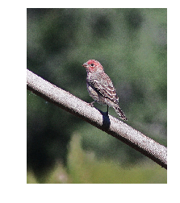

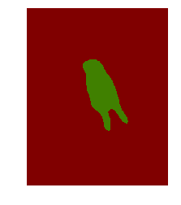

```python
# 读取一张图片看看结果
show_image('data/val_image/ILSVRC2012_val_00004375.JPEG')
show_image('output/result/pseudo_color_prediction/ILSVRC2012_val_00004375.png')
```

```python
# 将结果压缩到pred.zip中
def zipDir(dirpath,outFullName):
    zip = zipfile.ZipFile(outFullName,"w",zipfile.ZIP_DEFLATED)
    for path,dirnames,filenames in os.walk(dirpath):
        # 去掉目标跟路径，只对目标文件夹下边的文件及文件夹进行压缩
        fpath = path.replace(dirpath,'')

        for filename in filenames:
            zip.write(os.path.join(path,filename),os.path.join(fpath,filename))
    zip.close()
```

```python
# 压缩结果
image_file_path = "output/result/pseudo_color_prediction"
outFullName = 'pred.zip'
zipDir(image_file_path,outFullName)
```

# 三、预测数据及标签数据检查

## 0 预测图片检查

```python
image_file_path = "output/result/pseudo_color_prediction"
# 首先检查一下共有多少个图片
file_names = os.listdir(image_file_path)
file_names = sorted(file_names)
print(len(file_names))
print(file_names[0])
print(file_names[1])
print(os.path.join(image_file_path, file_names[0]) )
print(os.path.join(image_file_path, file_names[1]) )
# 去除非图片文件
for index, fn in enumerate(file_names):
    if '.png' not in fn:
        print(index)
        del(file_names[index])

print(len(file_names))
print(file_names[0])
print(file_names[1])
print(os.path.join(image_file_path, file_names[0]) )
print(os.path.join(image_file_path, file_names[1]) )
```

```
11856
ILSVRC2012_val_00000001.png
ILSVRC2012_val_00000004.png
output/result/pseudo_color_prediction/ILSVRC2012_val_00000001.png
output/result/pseudo_color_prediction/ILSVRC2012_val_00000004.png
11856
ILSVRC2012_val_00000001.png
ILSVRC2012_val_00000004.png
output/result/pseudo_color_prediction/ILSVRC2012_val_00000001.png
output/result/pseudo_color_prediction/ILSVRC2012_val_00000004.png
```

## 1 定义部分常用函数（显示图片，检查数值）

```python
# 显示图片函数
def show_image(image_1):
    lena = mpimg.imread(image_1,0)
    plt.imshow(lena) # 显示图片
    plt.axis('off') # 不显示坐标轴
    plt.show()
```

## 2 标签数据检查

[figure not shown]

```
(500, 333)
(0, 0, 0)
For the figure data/train_50k_mask/n01443537/n01443537_12860.png , there are 2 kinds of different values
[(0, 0, 0), (255, 255, 255)]
```

```python
# 查看图片及数值
def check_values(standard_label):
    # 展示图片
    show_image(standard_label)

    #读取一张图片，并显示其对应像素的通道数值
    img=Image.open(standard_label)
    img_array=img.load()
    print(img.size) # 图片大小
    print(img_array[0,0]) # [0,0]位置的通道数值

    # 检查该图片除了(0,0,0)以外是否有其他通道数值
    values = []
    for i in range(img.size[0]):
        for j in range(img.size[1]):
                if img_array[i,j] not in values:
                    values.append(img_array[i,j])

    print("For the figure " + standard_label +" , there are " + str(len(values)) + " kinds of different values")
    print(values)

standard_label = 'data/train_50k_mask/n01443537/n01443537_12860.png'
check_values(standard_label)
```